# Analysis of Income, Temperature, and Population Density in Spain 2020

Nykol Armacanqui and Labanya Paul

2025-07-07

### Setup

This section loads all necessary libraries and sets up the environment for the analysis.

### API and Data Configuration

Here, we configure the download folder and set up the API key for the Copernicus Climate Data Store (CDS) to download temperature data.

```
## [1] "3aa6e68c-6a56-4adb-a9c4-2e6220ac9806"
```

### Data Download: ERA5 Temperature

### Vector Data: Provincial Income

We will now load and process the income data. This involves reading a CSV file, aggregating municipal income to the provincial level, and joining it with spatial data for Spain’s provinces.

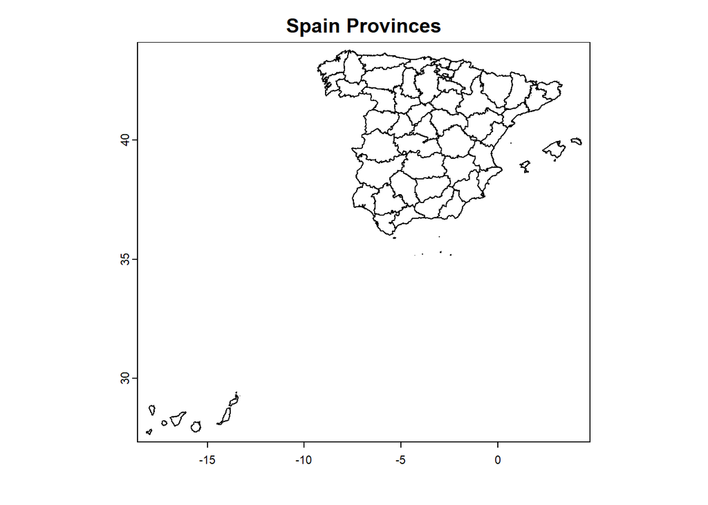

```
## # A tibble: 6 × 2
##   prov_name        mean_income
##   <chr>                  <dbl>
## 1 Albacete              10348.
## 2 Alicante/Alacant      10413.
## 3 Almería                9878.
## 4 Araba/Álava           14453.
## 5 Asturias              12572.
## 6 Avila                 11649.
```

```
##  [1] "Almería"                "Cádiz"                  "Córdoba"
##  [4] "Granada"                "Huelva"                 "Jaén"
##  [7] "Málaga"                 "Sevilla"                "Huesca"
## [10] "Teruel"                 "Zaragoza"               "Cantabria"
## [13] "Albacete"               "Ciudad Real"            "Cuenca"
## [16] "Guadalajara"            "Toledo"                 "Ávila"
## [19] "Burgos"                 "León"                   "Palencia"
## [22] "Salamanca"              "Segovia"                "Soria"
## [25] "Valladolid"             "Zamora"                 "Barcelona"
## [28] "Girona"                 "Lleida"                 "Tarragona"
## [31] "Ceuta"                  "Melilla"                "Madrid"
## [34] "Navarra"                "Alicante"               "Castellón"
## [37] "Valencia"               "Badajoz"                "Cáceres"
## [40] "A Coruña"               "Lugo"                   "Ourense"
## [43] "Pontevedra"             "Baleares"               "Las Palmas"
## [46] "Santa Cruz de Tenerife" "La Rioja"               "Álava"
## [49] "Guipúzcoa"              "Vizcaya"                "Asturias"
## [52] "Murcia"
```

```
##  [1] "Albacete"               "Alicante/Alacant"       "Almería"
##  [4] "Araba/Álava"            "Asturias"               "Avila"
##  [7] "Badajoz"                "Balears, Illes"         "Barcelona"
## [10] "Bizkaia"                "Burgos"                 "Cantabria"
## [13] "Castellón/Castelló"     "Ceuta"                  "Ciudad Real"
## [16] "Coruña, A"              "Cuenca"                 "Cáceres"
## [19] "Cádiz"                  "Córdoba"                "Gipuzkoa"
## [22] "Girona"                 "Granada"                "Guadalajara"
## [25] "Huelva"                 "Huesca"                 "Jaén"
## [28] "León"                   "Lleida"                 "Lugo"
## [31] "Madrid"                 "Melilla"                "Murcia"
## [34] "Málaga"                 "Navarra"                "Ourense"
## [37] "Palencia"               "Palmas, Las"            "Pontevedra"
## [40] "Rioja, La"              "Salamanca"              "Santa Cruz de Tenerife"
## [43] "Segovia"                "Sevilla"                "Soria"
## [46] "Tarragona"              "Teruel"                 "Toledo"
## [49] "Valencia/València"      "Valladolid"             "Zamora"
## [52] "Zaragoza"
```

### Joining Spatial and Income Data

Now we join the aggregated income data with the provincial boundaries.

### Map 1: Average Provincial Income

This map visualizes the average net income per capita for each province in Spain for the year 2020.

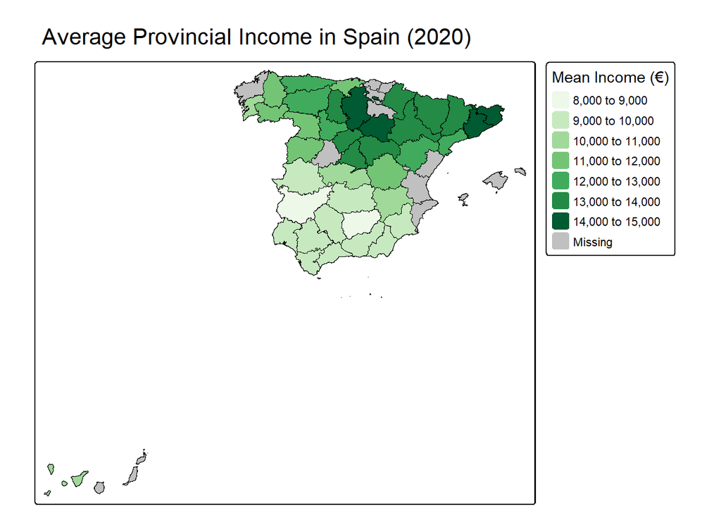

### Raster Data: Processing Temperature

Next, we load the downloaded temperature data, reproject it to match our vector data’s CRS, and join it to the boundaries of Spain.

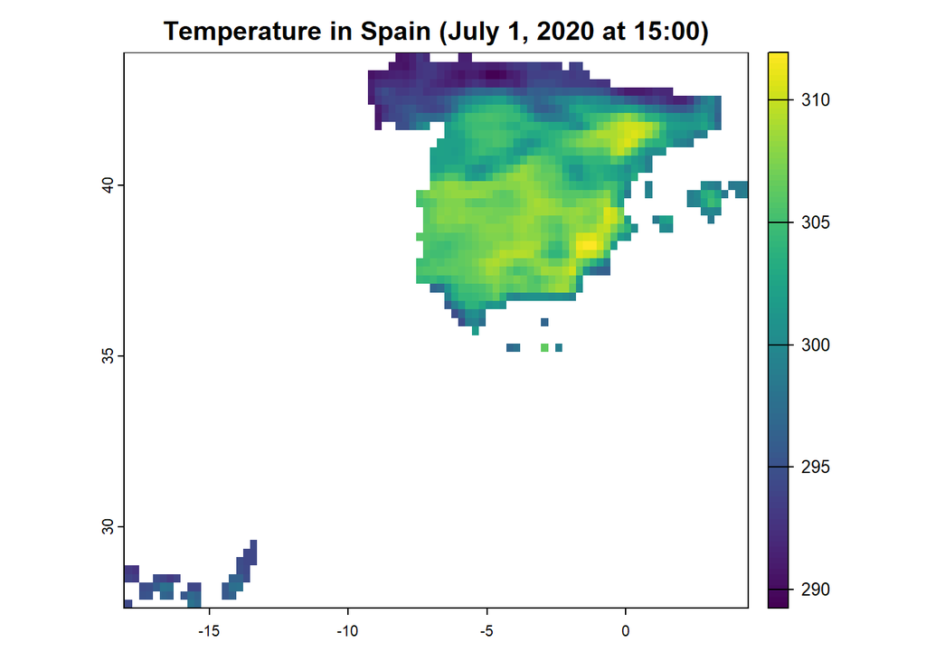

### Extracting Temperature and Filtering Data

We extract the mean temperature for each province and then filter the dataset to include only mainland Spain, removing the Canary Islands.

[output not shown]

```
## Simple feature collection with 6 features and 3 fields
## Geometry type: GEOMETRY
## Dimension:     XY
## Bounding box:  xmin: -7.522699 ymin: 35.93736 xmax: -1.630006 ymax: 38.72911
## Geodetic CRS:  WGS 84
##    NAME_2 mean_income mean_temp                       geometry
## 1 Almería    9877.608  306.9075 MULTIPOLYGON (((-3.030694 3...
## 2   Cádiz    9310.822  302.1615 MULTIPOLYGON (((-5.841249 3...
## 3 Córdoba    9425.026  307.7326 MULTIPOLYGON (((-4.248001 3...
## 4 Granada    9320.529  306.1231 POLYGON ((-3.351177 36.7284...
## 5  Huelva    9676.962  304.9515 MULTIPOLYGON (((-6.342219 3...
## 6    Jaén    8957.351  307.5160 POLYGON ((-4.030909 37.4433...
```

### Map 2: Average Provincial Temperature

This map shows the average temperature across mainland Spanish provinces.

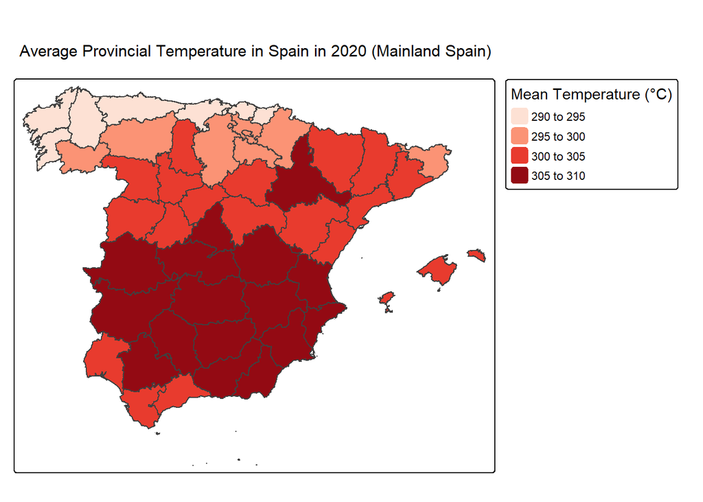

### Analysis 1: Simple Linear Regression (Income vs. Temperature)

We first look at the relationship between income and temperature with a scatterplot and then run a simple linear regression.

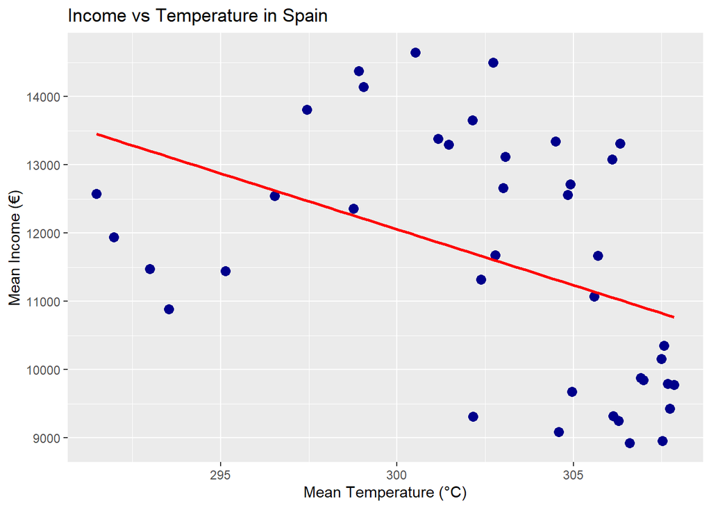

```
##
## Regression: Income vs Temperature
## ===============================================
##                         Dependent variable:
##                     ---------------------------
##                             mean_income
## -----------------------------------------------
## mean_temp                   -163.725***
##                              (55.137)
##
## Constant                   61,172.250***
##                            (16,685.810)
##
## -----------------------------------------------
## Observations                    40
## R2                             0.188
## Adjusted R2                    0.167
## Residual Std. Error     1,635.396 (df = 38)
## F Statistic            8.817*** (df = 1; 38)
## ===============================================
## Note:               *p<0.1; **p<0.05; ***p<0.01
```

```
##
## Call:
## lm(formula = mean_income ~ mean_temp, data = spain_prov_income)
##
## Residuals:
##     Min      1Q  Median      3Q     Max
## -2390.0 -1412.2  -213.5  1491.2  2886.4
##
## Coefficients:
##             Estimate Std. Error t value Pr(>|t|)
## (Intercept) 61172.25   16685.81   3.666  0.00075 ***
## mean_temp    -163.73      55.14  -2.969  0.00515 **
## ---
## Signif. codes:  0 '***' 0.001 '**' 0.01 '*' 0.05 '.' 0.1 ' ' 1
##
## Residual standard error: 1635 on 38 degrees of freedom
## Multiple R-squared:  0.1883, Adjusted R-squared:  0.167
## F-statistic: 8.817 on 1 and 38 DF,  p-value: 0.005146
```

### Raster Data: Processing Population Density

To improve our model, we introduce population density as a control variable. We load, process, and log transform the population density data.

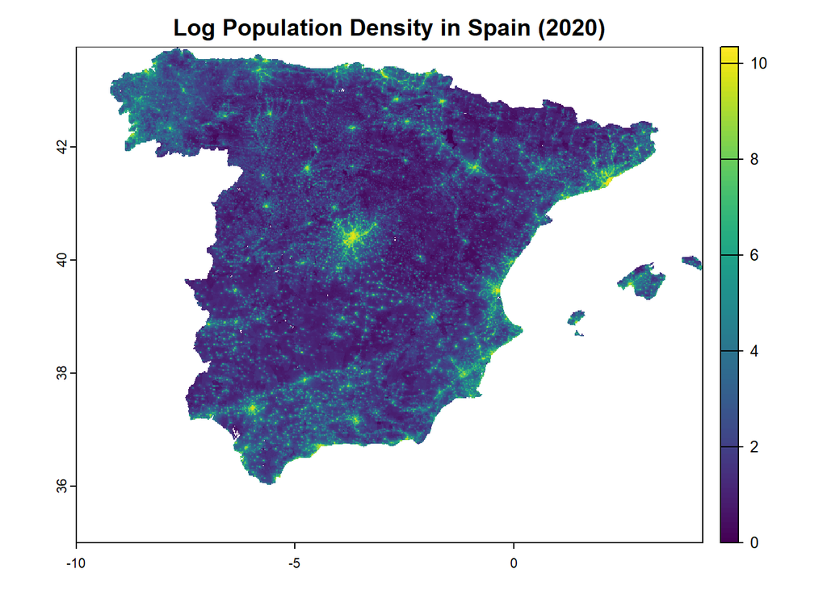

### Extracting Population Density and Finalizing Data

We extract the mean population density for each province and clean the dataset of any remaining NA values.

[output not shown]

```
## Simple feature collection with 6 features and 4 fields
## Geometry type: GEOMETRY
## Dimension:     XY
## Bounding box:  xmin: -7.522699 ymin: 35.93736 xmax: -1.630006 ymax: 38.72911
## Geodetic CRS:  WGS 84
##    NAME_2 mean_income mean_temp mean_popd                       geometry
## 1 Almería    9877.608  306.9075  2.538328 MULTIPOLYGON (((-3.030694 3...
## 2   Cádiz    9310.822  302.1615  3.028416 MULTIPOLYGON (((-5.841249 3...
## 3 Córdoba    9425.026  307.7326  2.071928 MULTIPOLYGON (((-4.248001 3...
## 4 Granada    9320.529  306.1231  2.317221 POLYGON ((-3.351177 36.7284...
## 5  Huelva    9676.962  304.9515  2.089108 MULTIPOLYGON (((-6.342219 3...
## 6    Jaén    8957.351  307.5160  2.121171 POLYGON ((-4.030909 37.4433...
```

A scatterplot helps show the relationship between provincial income and population density.

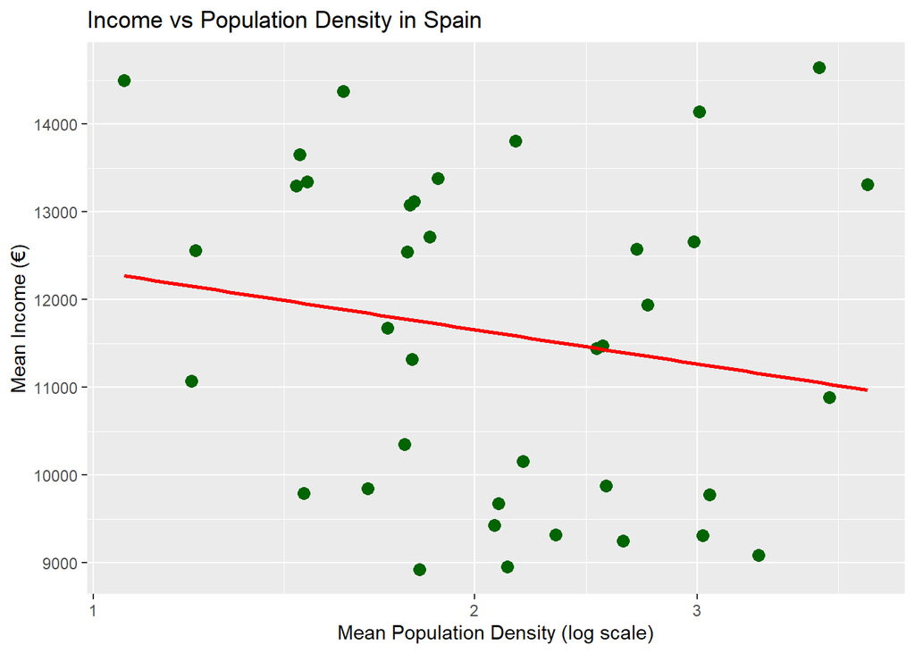

### Preparing Data for Final Maps

We create new columns to label income and identify the top 3 richest and bottom 3 poorest provinces.

```
## Simple feature collection with 3 features and 18 fields
## Geometry type: GEOMETRY
## Dimension:     XY
## Bounding box:  xmin: -4.335258 ymin: 41.05652 xmax: 2.777362 ymax: 43.19856
## Geodetic CRS:  WGS 84
##       GID_2 GID_0 COUNTRY   GID_1          NAME_1 NL_NAME_1    NAME_2 VARNAME_2
## 1 ESP.5.2_1   ESP   Spain ESP.5_1 Castilla y León      <NA>    Burgos      <NA>
## 2 ESP.5.7_1   ESP   Spain ESP.5_1 Castilla y León      <NA>     Soria      <NA>
## 3 ESP.6.1_1   ESP   Spain ESP.6_1        Cataluña      <NA> Barcelona      <NA>
##   NL_NAME_2    TYPE_2 ENGTYPE_2 CC_2   HASC_2 mean_income
## 1      <NA> Provincia  Province   09 ES.CL.BU    14369.85
## 2      <NA> Provincia  Province   42 ES.CL.SR    14493.98
## 3      <NA> Provincia  Province   08 ES.CT.BR    14646.80
##                         geometry mean_temp mean_popd income_label top3
## 1 MULTIPOLYGON (((-3.689104 4...  298.9179  1.574751       €14.4k TRUE
## 2 POLYGON ((-2.449446 41.0776...  302.7311  1.057132       €14.5k TRUE
## 3 MULTIPOLYGON (((1.998472 41...  300.5125  3.741299       €14.6k TRUE
```

```
## Simple feature collection with 3 features and 19 fields
## Geometry type: GEOMETRY
## Dimension:     XY
## Bounding box:  xmin: -7.335861 ymin: 36.30986 xmax: -2.436361 ymax: 39.45181
## Geodetic CRS:  WGS 84
##        GID_2 GID_0 COUNTRY    GID_1      NAME_1 NL_NAME_1  NAME_2 VARNAME_2
## 1  ESP.1.6_1   ESP   Spain  ESP.1_1   Andalucía      <NA>    Jaén      <NA>
## 2  ESP.1.7_1   ESP   Spain  ESP.1_1   Andalucía      <NA>  Málaga      <NA>
## 3 ESP.11.1_1   ESP   Spain ESP.11_1 Extremadura      <NA> Badajoz      <NA>
##   NL_NAME_2    TYPE_2 ENGTYPE_2 CC_2   HASC_2 mean_income
## 1      <NA> Provincia  Province   23 ES.AN.JA    8957.351
## 2      <NA> Provincia  Province   29 ES.AN.MG    9083.786
## 3      <NA> Provincia  Province   06 ES.EX.BD    8927.732
##                         geometry mean_temp mean_popd income_label  top3 bottom3
## 1 POLYGON ((-4.030909 37.4433...  307.5160  2.121171       €8.96k FALSE    TRUE
## 2 MULTIPOLYGON (((-5.319933 3...  304.5839  3.351224       €9.08k FALSE    TRUE
## 3 POLYGON ((-6.46565 38.03225...  306.5924  1.809093       €8.93k FALSE    TRUE
```

### Map 3: Population Density and Income

This map overlays mean income labels on population density. The top 3 richest provinces are highlighted in bold red.

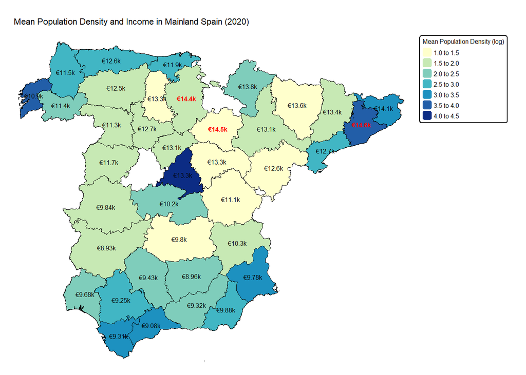

### Map 4: Temperature and Income

This map overlays mean income labels on mean temperature. The top 3 richest provinces are highlighted in blue, and the bottom 3 are in green.

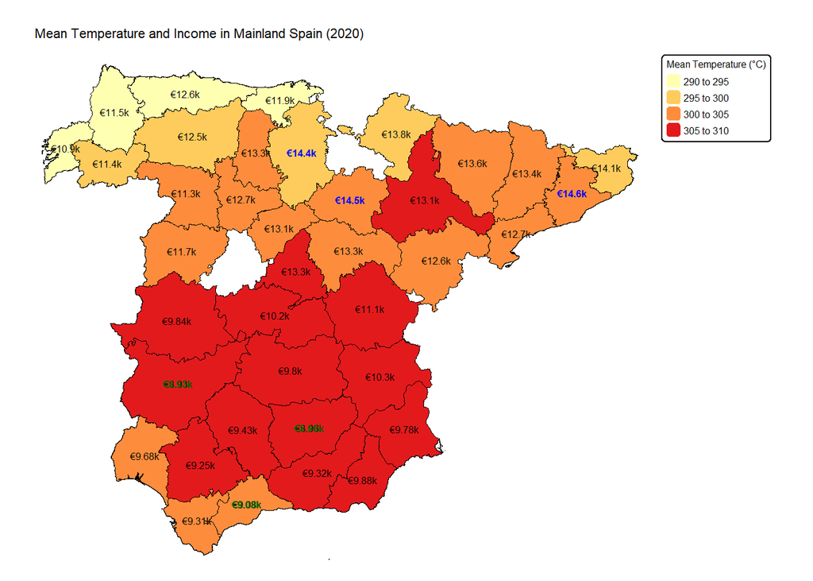

### Analysis 2: Multiple Linear Regression

Finally, we run a multiple linear regression model to assess the relationship between income and temperature while controlling for population density. We then compare this model to our earlier simple regression.

```
##
## Multiple Regression: Income vs Temperature and Population Density
## ===============================================
##                         Dependent variable:
##                     ---------------------------
##                             mean_income
## -----------------------------------------------
## mean_temp                   -187.094***
##                              (58.202)
##
## mean_popd                    -555.786
##                              (368.569)
##
## Constant                   69,459.030***
##                            (17,835.440)
##
## -----------------------------------------------
## Observations                    38
## R2                             0.237
## Adjusted R2                    0.193
## Residual Std. Error     1,648.672 (df = 35)
## F Statistic            5.433*** (df = 2; 35)
## ===============================================
## Note:               *p<0.1; **p<0.05; ***p<0.01
```

```
##
## Comparing Simple OLS and OLS with POP Control
## =========================================================================================
##                                                      Dependent variable:
##                                      ----------------------------------------------------
##                                                        Mean Income (€)
##                                           Simple OLS       Control for Population Density
## -----------------------------------------------------------------------------------------
## Mean Temperature (°C)                     -163.725***               -187.094***
##                                            (55.137)                   (58.202)
##
## Mean Population Density (people/km²)                                  -555.786
##                                                                      (368.569)
##
## Constant                                 61,172.250***             69,459.030***
##                                          (16,685.810)               (17,835.440)
##
## -----------------------------------------------------------------------------------------
## Observations                                  40                         38
## R2                                           0.188                     0.237
## Adjusted R2                                  0.167                     0.193
## Residual Std. Error                   1,635.396 (df = 38)       1,648.672 (df = 35)
## F Statistic                          8.817*** (df = 1; 38)     5.433*** (df = 2; 35)
## =========================================================================================
## Note:                                                         *p<0.1; **p<0.05; ***p<0.01
```